# Assignment 1: Data Set Selection and Initial Processing

Vishali Umaiyalan

# 0. Libraries

```r
require(GEOquery)
require(data.table)
require(edgeR)
require(biomaRt)
require(ggplot2)
require(gridExtra)
```

# 1. Introduction to chosen dataset

The chosen dataset comes from “Integrated functional genomic analyses of Klinefelter and Turner syndromes reveal global network effects of altered X chromosome dosage” which was published in February, 2020 by Zhang et. al. The authors of this paper were interested in differential expression between control individuals and individuals either Klinefelter or Turner syndrom (KS and TS, respectively). KS occurs in males when they are born with an extra X chromosome (i.e. XXY). On the other hand, TS occurs in females when they are born missing an X chromosome (i.e. XO).

# 2. Download and analyze the data

```r
# Get the author's summary for the chosen data set
geo_id <- "GSE126712"
gse <- suppressMessages(getGEO(GEO = geo_id,
                                 GSEMatrix = FALSE))
gse@header$summary[1]
```

```
## [1] "Background: In both Turner syndrome (TS) and Klinefelter syndrome (KS) copy number aberrations of the X chromosome lead to various developmental symptoms. To date there has not been a comprehensive and directly comparative analysis of TS vs. KS regarding the changes on the molecular level"
```

```r
# Download the expression data

# Create a data folder in the current working directory
dest_dir <- file.path(getwd(), "data")
if (! dir.exists(dest_dir)) {
  dir.create(dest_dir)
}

file_names <- getGEOSuppFiles(geo_id,
                              makeDirectory = FALSE,
                              fetch_files = FALSE)
file_names$fname
```

```
## [1] "GSE126712_RAW.tar"
```

```r
raw_file_path <- file.path(dest_dir, file_names$fname)

# There is only one file associated with this dataset
# Download the file in the data directory that was created in the previous step
if (! file.exists(raw_file_path)){
  sfiles <- getGEOSuppFiles(GEO = geo_id,
                            makeDirectory = FALSE,
                            baseDir = dest_dir,
                            fetch_files = TRUE)
  # Unzip the .tar file
  untar(raw_file_path, exdir = dest_dir)
}
```

# 3. Clean the data

```r
# The original downloaded data as counts for each individual are stored in
# separate files. Each file has these coloumns: gene_id, transcript_ids, length,
# effective_length, expected_count, TPM, and FPKM. Combine all the data files
# into one count matrix where each row is the gene, each column is the sample,
# and each cell stores the expected_count for the gene in that sample.

# A helper function: add a sample name column to the dataframe that is stored
# at the given file path
add_name_to_counts <- function(file_path, sample_name) {
  df <- fread(file_path, select = c("gene_id", "expected_count"))
  df$sample <- sample_name
  return(df)
}

# Check if this step has already been done
if (file.exists("data/original_combined_counts.rds")) {
  combined_counts <- readRDS("data/original_combined_counts.rds")
} else {
  # List all the count files (should have 54 since there are 54 donors in the study)
  count_files <- list.files(dest_dir,
                            pattern = "genes.results.txt.gz$",
                            full.names = TRUE)

  # Initialize an empty list to store multiple data frames
  df_list <- list()

  # Loop through each file, read, and store in list
  for (file_path in count_files) {
    sample_name <- gsub(".*_(.*)\\.genes\\.results\\.txt\\.gz$",
                        "\\1",
                        basename(file_path))
    df_list[[sample_name]] <- add_name_to_counts(file_path,
                                                 sample_name)
  }

  # Combine all data.tables into one
  combined_df <- rbindlist(df_list,
                           use.names = TRUE,
                           fill = TRUE)

  # Reshape to wide format and convert to a matrix
  wide_df <- dcast(combined_df, gene_id ~ sample, value.var = "expected_count")
  row.names(wide_df) <- wide_df$gene_id

  # Remove the gene coloumn and adds gene names as rownames in the matrix
  combined_counts <- data.matrix(wide_df[, -1], )
  row.names(combined_counts) <- wide_df$gene_id

  saveRDS(combined_counts, "data/original_combined_counts.rds")
}
```

```r
# Each sample is a unique number. Add the condition to the sample name

# IDs for individuals with Turner's syndrome
ts_ids <- c("13880", "14307", "14356", "14552", "14465", "14782", "15190",
            "15830", "15938", "18447", "18463", "18825", "18968", "19484")

# IDs for individuals with Klienfelter's syndrome
ks_ids <- c("18411", "18419", "18452", "18466", "18499", "18525", "18632",
            "18833", "18886", "19150", "19197", "19355", "19360")

# IDs for female controls
control_female_ids <- c("14356", "15622", "16054", "18076", "18102", "18226",
                        "18426", "18501", "18576", "19117", "19293", "19406",
                        "19426", "19630")

# IDs for male controls
control_male_ids <- c("15915", "16053", "17972", "18465", "18467", "18665",
                      "18707", "18805", "19018", "19169", "19170", "19198",
                      "19361")

current_sample_names <- colnames(combined_counts)
updated_sample_names <- current_sample_names

# Update sample names based on condition using the id mappings above
for (i in seq_along(current_sample_names)) {
  sample_id <- current_sample_names[i]

  if (sample_id %in% ts_ids) {
    updated_sample_names[i] <- paste(sample_id, "TS", sep = "_")
  } else if (sample_id %in% ks_ids) {
    updated_sample_names[i] <- paste(sample_id, "KS", sep = "_")
  } else if (sample_id %in% control_female_ids) {
    updated_sample_names[i] <- paste(sample_id, "control_female", sep = "_")
  } else if (sample_id %in% control_male_ids) {
    updated_sample_names[i] <- paste(sample_id, "control_male", sep = "_")
  }
}

colnames(combined_counts) <- updated_sample_names
```

```r
# Summarize the number of individuals in each group in the data
num_ts <- length(ts_ids)
num_ks <- length(ks_ids)
num_control_female <- length(control_female_ids)
num_control_male <- length(control_male_ids)

sample_condition_counts <- data.frame(
  condition = c("Turner's Syndrome", "Klinefelter's Syndrome", "Female Controls", "Male Controls"),
  number_of_samples = c(num_ts, num_ks, num_control_female, num_control_male)
)

sample_condition_counts
```

```
##                condition number_of_samples
## 1      Turner's Syndrome                14
## 2 Klinefelter's Syndrome                13
## 3        Female Controls                14
## 4          Male Controls                13
```

```r
# The gene names are already mapped to HUGO gene symbols, but they are combined
# with the Ensembl gene identifiers (e.g. ensemblID_HUGO) Extract the HUGO gene
# symbols and make these gene symbols the row names in the counts matrix
current_row_names <- rownames(combined_counts)
HUGO_names <- sapply(strsplit(current_row_names, "_", fixed = TRUE),
                     function(x) x[2])
ensembl_ids_version <- sapply(strsplit(current_row_names, "_", fixed = TRUE),
                              function(x) x[1])
ensembl_ids <- sapply(ensembl_ids_version, function(x) sub("\\..*", "", x))


# Manually convert the ensembl gene IDs to the HUGO gene symbol
# Use the ensembl gene IDs without the version to avoid filtering more genes
conversion_stash <- "data/id_conversion.rds"

ensembl <- useDataset("hsapiens_gene_ensembl", mart = useMart("ensembl"))

if (file.exists(conversion_stash)) {
  id_conversion <- readRDS(conversion_stash)
} else {
  id_conversion <- getBM(attributes = c("ensembl_gene_id", "hgnc_symbol"),
                         filters = c("ensembl_gene_id"),
                         values = ensembl_ids,
                         mart = ensembl)
  saveRDS(id_conversion, conversion_stash)
}

# Convert the counts matrix into a data frame object for now
combined_counts_df <- as.data.frame(combined_counts)
combined_counts_df$ensembl_ids <- ensembl_ids
combined_counts_df$HUGO_names <- HUGO_names

# Add the HUGO symbols that were found manually
combined_counts_df <- merge(combined_counts_df,
                            id_conversion,
                            by.x = "ensembl_ids",
                            by.y = "ensembl_gene_id",
                            all.x = TRUE)

# Only keep the rows where the original HUGO gene symbol matches with the
# manually found HUGO symbol
combined_counts_df <- combined_counts_df[combined_counts_df$HUGO_names == combined_counts_df$hgnc_symbol, ]
combined_counts_df<- subset(combined_counts_df, hgnc_symbol != "" &
                              !is.na(hgnc_symbol))

# Convert back to a matrix
row_names_for_matrix <- combined_counts_df$hgnc_symbol
combined_counts_df <- combined_counts_df[, !(names(combined_counts_df) %in%
                                               c("ensembl_ids", "HUGO_names", "hgnc_symbol"))]
combined_counts <- as.matrix(combined_counts_df)
rownames(combined_counts) <- row_names_for_matrix
```

```r
# Filter out genes with low counts
min_num_samples <- 3
keep <- rowSums(cpm(combined_counts) >1) > min_num_samples
filtered_counts <- combined_counts[keep, ]
```

```r
# Check if some genes have multiple rows
nrow(filtered_counts) == length(unique(rownames(filtered_counts))) # TRUE
```

```
## [1] TRUE
```

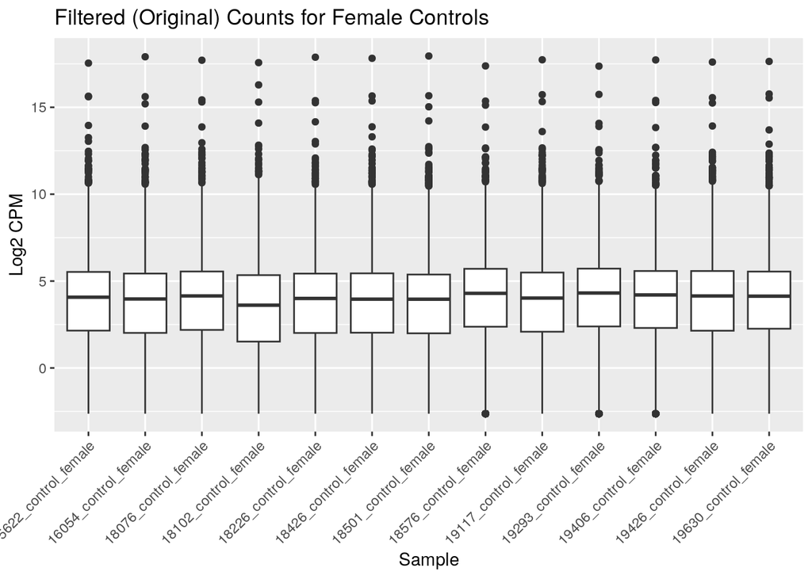

```r
# Make boxplots for individuals in each condition to determine if there are
# any outliers
counts_cpm <- cpm(filtered_counts, log = TRUE)
long_counts <- suppressWarnings(melt(as.matrix(counts_cpm)))
colnames(long_counts) <- c("Gene", "Sample", "Expression")
long_counts$Condition <- gsub(".*_(.*)$", "\\1", long_counts$Sample)

# Convert data to separate dataframes for easy plotting
data_female_control <- subset(long_counts, Condition == "female")
data_male_control <- subset(long_counts, Condition == "male")
data_ts <- subset(long_counts, Condition == "TS")
data_ks <- subset(long_counts, Condition == "KS")

p_female_control <- ggplot(data_female_control, aes(x = Sample, y = Expression)) +
  geom_boxplot() +
  theme(axis.text.x = element_text(angle = 45, hjust = 1)) +
  labs(title = "Filtered (Original) Counts for Female Controls", x = "Sample", y = "Log2 CPM")
p_female_control
```

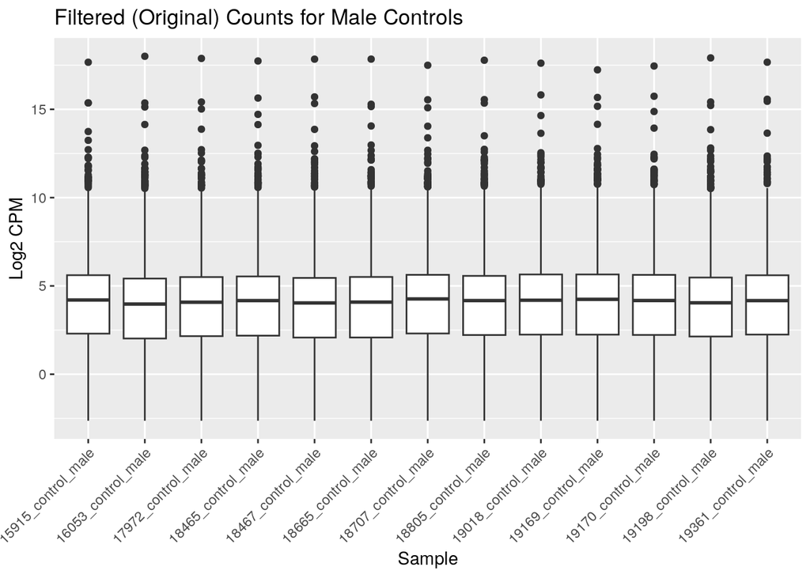

```r
p_male_control <- ggplot(data_male_control, aes(x = Sample, y = Expression)) +
  geom_boxplot() +
  theme(axis.text.x = element_text(angle = 45, hjust = 1)) +
  labs(title = "Filtered (Original) Counts for Male Controls", x = "Sample", y = "Log2 CPM")
p_male_control
```

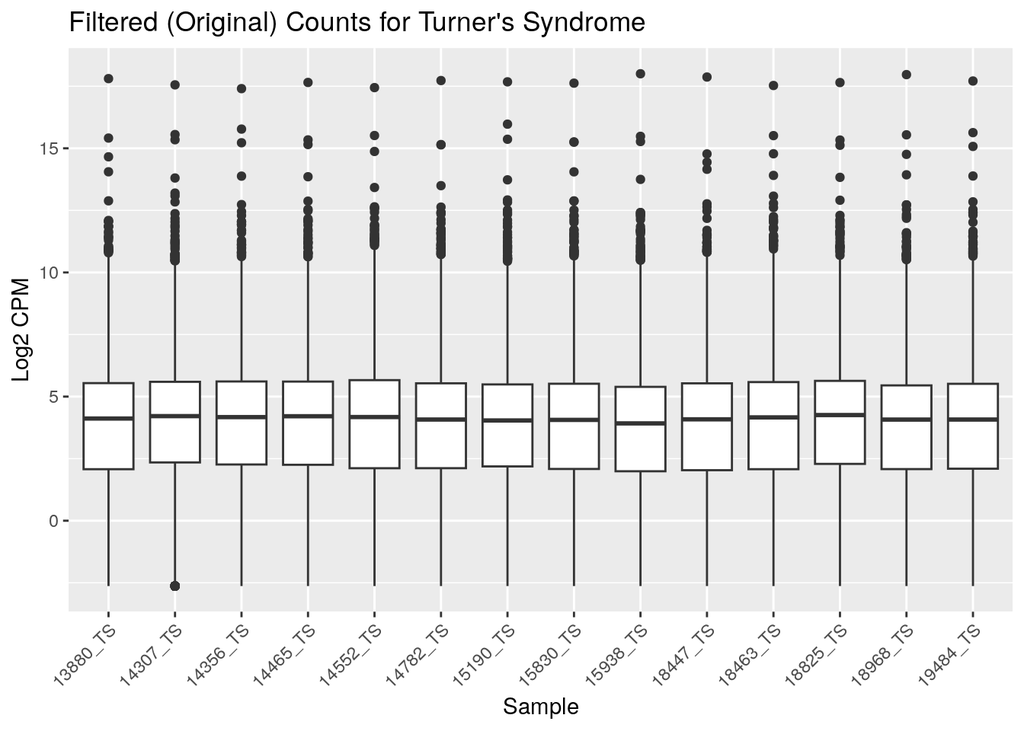

```r
# Plot for Turner's Syndrome
p_ts <- ggplot(data_ts, aes(x = Sample, y = Expression)) +
  geom_boxplot() +
  theme(axis.text.x = element_text(angle = 45, hjust = 1)) +
  labs(title = "Filtered (Original) Counts for Turner's Syndrome", x = "Sample", y = "Log2 CPM")
p_ts
```

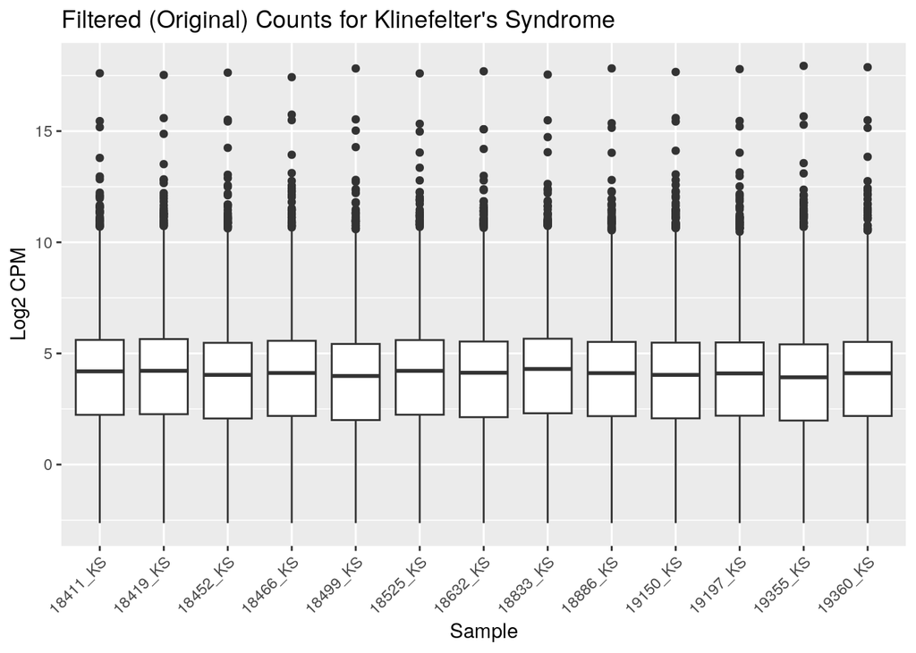

```r
# Plot for Klinefelter's Syndrome
p_ks <- ggplot(data_ks, aes(x = Sample, y = Expression)) +
  geom_boxplot() +
  theme(axis.text.x = element_text(angle = 45, hjust = 1)) +
  labs(title = "Filtered (Original) Counts for Klinefelter's Syndrome", x = "Sample", y = "Log2 CPM")
p_ks
```

# 4. Normalize the data

```r
d <- DGEList(counts = filtered_counts)
d <- calcNormFactors(d)

normalized_counts <- cpm(d)

# Save the normalized counts so we do not have to re-run this analysis later
saveRDS(normalized_counts, file = "data/normalized_counts.rds")
```

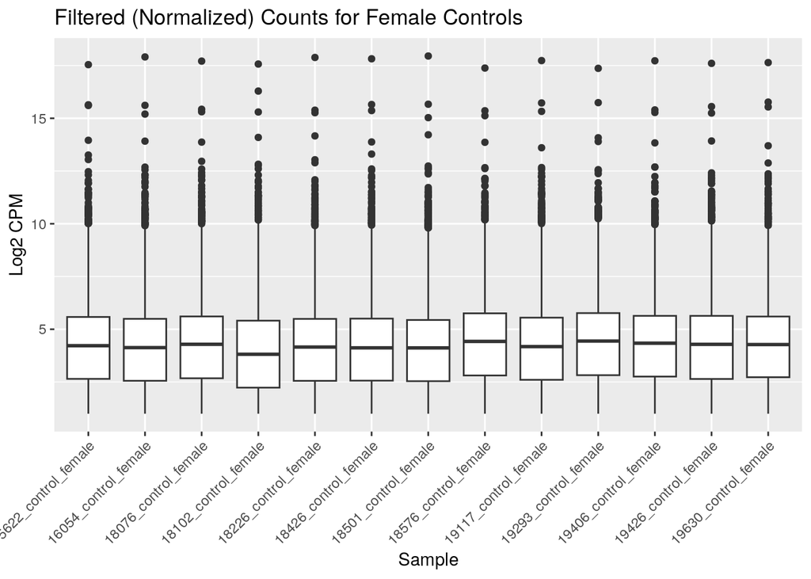

```r
# Make boxplots for individuals in each condition to determine if there are
# any outliers
normalized_counts_cpm <- cpm(normalized_counts, log = TRUE)
long_counts_normalized <- suppressWarnings(melt(as.matrix(normalized_counts_cpm)))
colnames(long_counts_normalized) <- c("Gene", "Sample", "Expression")
long_counts_normalized$Condition <- gsub(".*_(.*)$", "\\1", long_counts_normalized$Sample)

# Convert data to separate dataframes for easy plotting
data_female_control <- subset(long_counts_normalized, Condition == "female")
data_male_control <- subset(long_counts_normalized, Condition == "male")
data_ts <- subset(long_counts_normalized, Condition == "TS")
data_ks <- subset(long_counts_normalized, Condition == "KS")

p_female_control <- ggplot(data_female_control, aes(x = Sample, y = Expression)) +
  geom_boxplot() +
  theme(axis.text.x = element_text(angle = 45, hjust = 1)) +
  labs(title = "Filtered (Normalized) Counts for Female Controls", x = "Sample", y = "Log2 CPM")
p_female_control
```

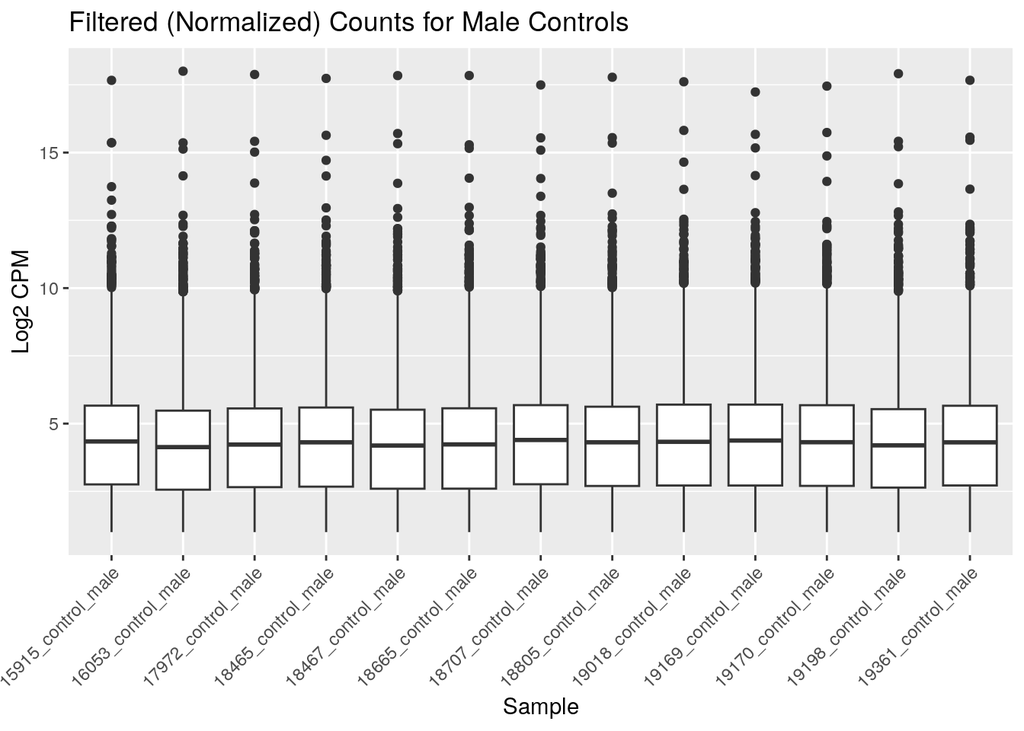

```r
p_male_control <- ggplot(data_male_control, aes(x = Sample, y = Expression)) +
  geom_boxplot() +
  theme(axis.text.x = element_text(angle = 45, hjust = 1)) +
  labs(title = "Filtered (Normalized) Counts for Male Controls", x = "Sample", y = "Log2 CPM")
p_male_control
```

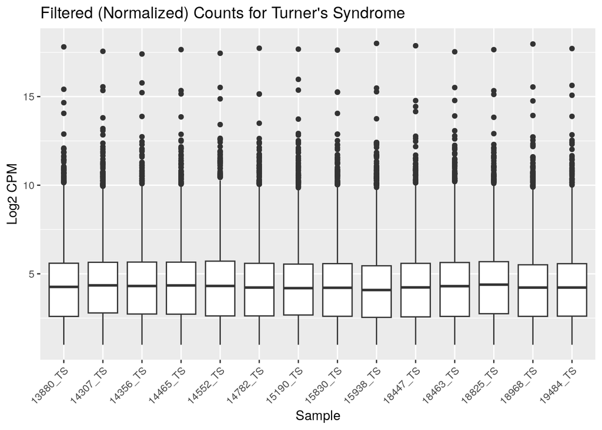

```r
# Plot for Turner's Syndrome
p_ts <- ggplot(data_ts, aes(x = Sample, y = Expression)) +
  geom_boxplot() +
  theme(axis.text.x = element_text(angle = 45, hjust = 1)) +
  labs(title = "Filtered (Normalized) Counts for Turner's Syndrome", x = "Sample", y = "Log2 CPM")
p_ts
```

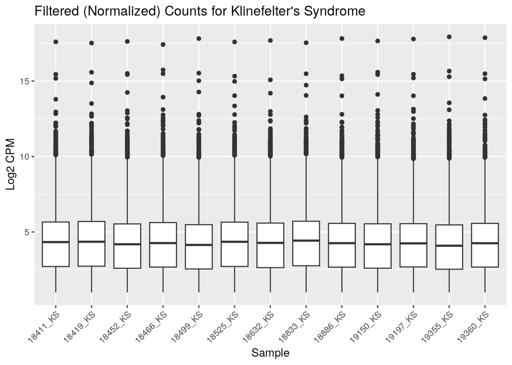

```r
# Plot for Klinefelter's Syndrome
p_ks <- ggplot(data_ks, aes(x = Sample, y = Expression)) +
  geom_boxplot() +
  theme(axis.text.x = element_text(angle = 45, hjust = 1)) +
  labs(title = "Filtered (Normalized) Counts for Klinefelter's Syndrome", x = "Sample", y = "Log2 CPM")
p_ks
```

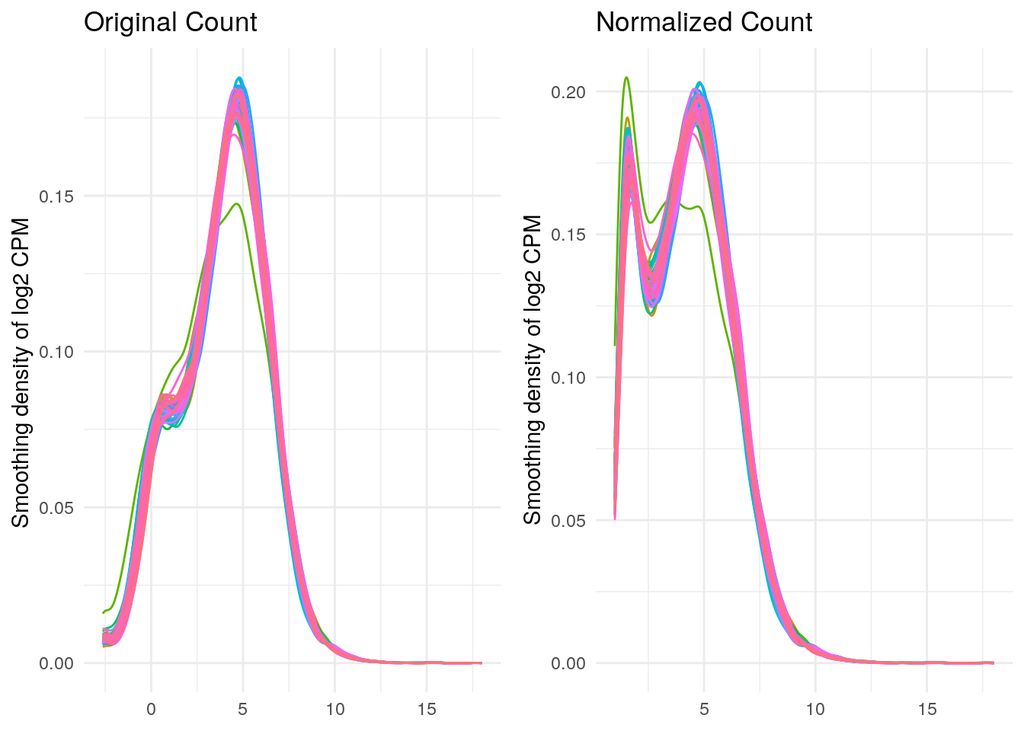

```r
# Plot the smoothing density of the log2 CPM counts for the original and normalized
# data
p_original <- ggplot(long_counts, aes(x = Expression, color = Sample)) +
  geom_density() +
  labs(title = "Original Count", x = NULL, y = "Smoothing density of log2 CPM ") +
  theme_minimal() +
  theme(legend.position = "none")

p_normalized <- ggplot(long_counts_normalized, aes(x = Expression, color = Sample)) +
  geom_density() +
  labs(title = "Normalized Count", x = NULL, y = "Smoothing density of log2 CPM") +
  theme_minimal() +
  theme(legend.position = "none")

grid.arrange(p_original, p_normalized, ncol = 2)
```